# Exponential Distribution vs Central Limit Theorem

## Statistical Inference

#### 2015-10-21

### Description and goals

Investigate the exponential distribution in R and compare it with the Central Limit Theorem. The exponential distribution can be simulated in R with rexp(n, lambda) where lambda is the rate parameter. The mean of exponential distribution is 1/lambda and the standard deviation is also 1/lambda. Using lambda = 0.2 for all of the simulations this paper will focus on investigate the distribution of averages of 40 exponentials.

Will be Illustrated via simulation and associated explanatory text the properties of the distribution of the mean of 40 exponentials.

For this aim this paper will be divided in 3 topics:

1. Show the sample mean and compare it to the theoretical mean of the distribution.
2. Show how variable the sample is (via variance) and compare it to the theoretical variance of the distribution.
3. Show that the distribution is approximately normal.

### Simulation

In order to create the dataset we will run a serie of 1000 simulations with 40 sampling size (observations) and as has been mentioned before the expoential distribution set to `rexp(40, 0.2)`.

Following the code:

```
# ggplot plotting library
library(ggplot2)

# defined values for the simulation
simulations <- 1000
lambda <- 0.2
observations <- 40

# the seed need to be set so for each generation we will generated
# the same randome values for the graph.

set.seed(108)

# Random Simulation
sample = rep(0,simulations)
for (i in 1:simulations) sample[i] = mean(rexp(observations,rate=lambda))
```

For an easier overview we can plot the sample:

```
# sample plot with histogram chart, bandwidth set between 0.1 - 0.5 show the
# distribution correctly.
ggp <- ggplot() + aes(sample) +
  geom_histogram(binwidth=0.25, colour="black", fill="lightblue") + theme_bw() +
  labs(x = "mean", y = expression("Density")) +
  labs(title=expression("Exponential distribution (1000 Simulation, 40 Samples, λ = 0.2)"))
print(ggp)
```

And the histogram ploted:

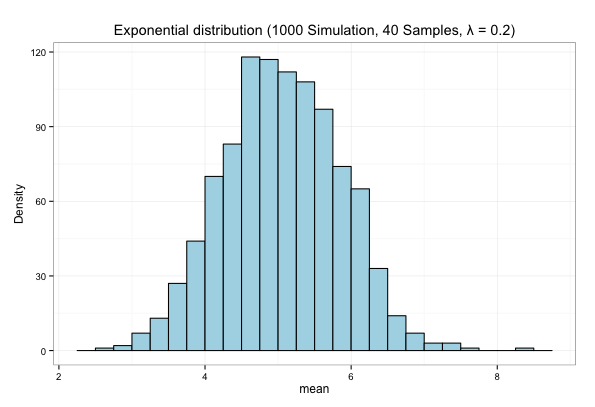

### Sample mean and the theoretical mean of the distribution

As is shown bellow the value of the sample mean is `5.058108` and the theoretical is `5`. The mean of exponential distribution and the theoretical mean of the distribution are quite close.

From the sample:

```
# actual mean of the sample data
mean_sample <- mean(sample)
```

```
> mean_sample
[1] 5.058108
```

Theoretical:

```
# theoretical mean
theoretical_mean <- 1/lambda
```

```
> theoretical_mean
[1] 5
```

### Variability, sample variance compared to the theoretical variance of the distribution

As is shown bellow the value of the sample variance is `0.6435606` and the theoretical is `0.625`, this results implies that the mean from the sample is very close to the theoretical mean of normal data.

From the sample:

```
# variance for the sample data
sample_variance <- var(sample)
```

```
> sample_variance
[1] 0.6435606
```

Theoretical:

```
# theorical_variance
theoretical_variance <- (1/lambda)^2/observations
```

```
> theoretical_variance
[1] 0.625
```

Bellow a graphical overview of both means and variances and its code:

```
ggp <- ggplot() + aes(sample) +
  geom_histogram(binwidth=0.25, colour="black", fill="lightblue") + theme_bw() +
  # Vertical lines for Sample and Theoretical Mean and Variance
  geom_vline(xintercept = sample_mean, colour="green", linetype = "dashed", size = 1.5) +
  geom_vline(xintercept = theoretical_mean, colour="red", linetype = "dashed", size = 1.5) +
  geom_vline(xintercept = sample_mean+sample_variance, colour="green", linetype = "dotted", size = 1.5) +
  geom_vline(xintercept = sample_mean-sample_variance, colour="green", linetype = "dotted", size = 1.5) +
  geom_vline(xintercept = theoretical_mean+theoretical_variance, colour="red", linetype = "dotted", size = 1.5) +
  geom_vline(xintercept = theoretical_mean-theoretical_variance, colour="red", linetype = "dotted", size = 1.5) +
  labs(x = "mean", y = expression("Density")) +
  labs(title=expression("Exponential distribution (1000 Simulation, 40 Samples, λ = 0.2)"))
print(ggp)
```

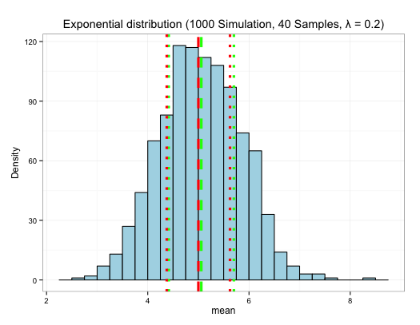

## Distribution approximately normal

In order to prove that the distribution is approximately normal, first we will create a histogram with a normal distribution and see how fits with the sample. Bellow the code and graph:

```
## Distribution approximately normalplotdata <- data.frame(sim_mean);
plotdata <- data.frame(sample)
ggp <- ggplot(plotdata, aes(x =sample)) +
  geom_histogram(aes(y=..density..), binwidth=0.25, colour="black", fill = "lightblue") +
  geom_vline(xintercept=theoretical_mean,size=1.0, color="green",linetype ="longdash") +
  geom_vline(xintercept=sample_mean,size=1.0, color="red",linetype = "longdash") +
  stat_function(fun=dnorm,args=list( mean=theoretical_mean, sd=sqrt(theoretical_variance)),color = "green", size = 1.0) +
  stat_function(fun=dnorm,args=list( mean=sample_mean, sd=sqrt(sample_variance)),color = "red", size = 1.0) +
  labs(title=expression("Exponential distribution (1000 Simulation, 40 Samples, λ = 0.2)"), x = "mean", y = expression("Density"))
print(ggp)
```

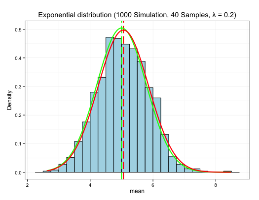

Based on the above graph, we can conclude that the distribution of the sample mean can be considered as a normal distributed.

### Confidence interval

Following we will compare the 95% confidence interval for both and prove that they are quite close. From the sample:

```
sample_ci <- round (mean(sample) + c(-1,1)*1.96*sd(sample)/sqrt(observations),3)
```

```
> sample_ci
[1] 4.809 5.307
```

Theoretical:

```
theoretical_ci <- theoretical_mean + c(-1,1)*1.96*sqrt(theoretical_variance)/sqrt(observations)
```

```
> theoretical_ci
[1] 4.755 5.245
```

Based on the results we can conclude that the confidence interval for the sample mean `[4.809, 5.307]` and the theoretical confidence interval `[4.755, 5.245]` are quite close.

### Normal Q-Q Plot Quantiles

```
# Normal Q-Q Plot
qqnorm(sample)
qqline(sample)
```

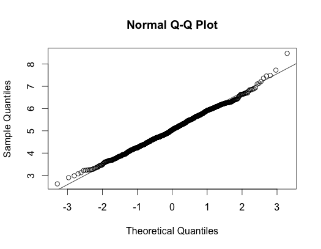

### Concusions

We can conclude that the distribution of the sample data is approximately normaly distributed.